Research Article

APPLIED ECOLOGY

# Habitat fragmentation and its lasting impact on Earth’s ecosystems

Nick M. Haddad nick_haddad@ncsu.eduLars A. Brudvig[...]John R. Townshend Authors Info & Affiliations

Science Advances • 20 Mar 2015 • Vol 1, Issue 2 • [DOI: 10.1126/sciadv.1500052](https://doi.org/10.1126/sciadv.1500052)

## Abstract

We conducted an analysis of global forest cover to reveal that 70% of remaining forest is within 1 km of the forest’s edge, subject to the degrading effects of fragmentation. A synthesis of fragmentation experiments spanning multiple biomes and scales, five continents, and 35 years demonstrates that habitat fragmentation reduces biodiversity by 13 to 75% and impairs key ecosystem functions by decreasing biomass and altering nutrient cycles. Effects are greatest in the smallest and most isolated fragments, and they magnify with the passage of time. These findings indicate an urgent need for conservation and restoration measures to improve landscape connectivity, which will reduce extinction rates and help maintain ecosystem services.

## INTRODUCTION

Destruction and degradation of natural ecosystems are the primary causes of declines in global biodiversity (*1*, *2*). Habitat destruction typically leads to fragmentation, the division of habitat into smaller and more isolated fragments separated by a matrix of human-transformed land cover. The loss of area, increase in isolation, and greater exposure to human land uses along fragment edges initiate long-term changes to the structure and function of the remaining fragments (*3*).

Ecologists agree that habitat destruction is detrimental to the maintenance of biodiversity, but they disagree—often strongly—on the extent to which fragmentation itself is to blame (*4*, *5*). Early hypotheses based on the biogeography of oceanic islands (*6*) provided a theoretical framework to understand fragmentation’s effect on extinction in terrestrial landscapes composed of “islands” of natural habitat scattered across a “sea” of human-transformed habitat. Central to the controversy has been a lingering uncertainty about the role of decreased fragment size and increased isolation relative to the widespread and pervasive effects of habitat loss in explaining declines in biodiversity and the degradation of ecosystems (*7*). Observational studies of the effects of fragmentation have often magnified the controversy because inference from nonmanipulative studies is limited to correlation and because they have individually often considered only single aspects of fragmentation (for example, edge, isolation, and area) (*8*). However, together with these correlative observations, experimental studies reveal that fragmentation has multiple simultaneous effects that are interwoven in complex ways and that operate over potentially long time scales (*9*).

Here, we draw on findings of the world’s largest and longest-running fragmentation experiments that span 35 years and disparate biomes on five continents. Their rigorous designs and long-term implementation overcome many limitations of observational studies. In particular, by manipulating and isolating individual aspects of fragmentation while controlling for others, and by doing so on entire ecosystems, they provide a powerful way to disentangle cause and effect in fragmented landscapes. Here, we present experimental evidence of unexpected long-term ecological changes caused by habitat fragmentation.

Highlighting one ecosystem type as an example, we first present a global analysis of the fragmentation of forest ecosystems, quantifying for the first time the global hotspots of intensive historical fragmentation. We then synthesize results from the set of long-term experiments conducted in a wide variety of ecosystems to demonstrate consistent impacts of fragmentation, how those impacts change over time, and how they align with predictions from theory and observation. Finally, we identify key knowledge gaps for the next generation of fragmentation experiments.

## GLOBAL ANALYSIS OF THE EXTREME MAGNITUDE AND EXTENT OF FRAGMENTATION

New satellite data sets reveal at high resolution how human activities are transforming global ecosystems. Foremost among these observations are those of forest cover because of the high contrast between forest and anthropogenic land cover types. Deforestation, which was already widespread in temperate regions in the mid-18th to 20th centuries and increased in the tropics over the past half century, has resulted in the loss of more than a third of all forest cover worldwide (*10*, *11*). Beyond the direct impacts of forest loss and expanding anthropogenic land cover (for example, agricultural fields and urban areas), remnant forests are likely to suffer from being smaller, more isolated, and with a greater area located near the edge of the forest (*12*).

We analyzed the world’s first high-resolution map of global tree cover (*13*) to measure the magnitude of forest fragmentation. This analysis revealed that nearly 20% of the world’s remaining forest is within 100 m of an edge (Fig. 1, A and B)—in close proximity to agricultural, urban, or other modified environments where impacts on forest ecosystems are most severe (*14*). More than 70% of the world’s forests are within 1 km of a forest edge. Thus, most forests are well within the range where human activities, altered microclimate, and nonforest species may influence and degrade forest ecosystems (*15*). The largest contiguous expanses of remaining forests are in the humid tropical regions of the Amazon and Congo River Basins (Fig. 1A). Large areas of more disjunct forest also remain in southeastern Asia, New Guinea, and the boreal biomes.

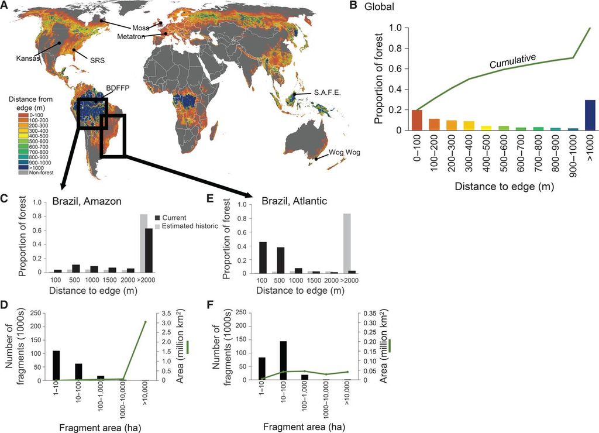

Fig. 1 The global magnitude of forest fragmentation.

(**A**) Mean distance to forest edge for forested pixels within each 1-km cell. Lines point to locations of ongoing fragmentation experiments identified and described in Fig. 2. (**B**) Proportion of the world’s forest at each distance to the forest edge and the cumulative proportion across increasing distance categories (green line). (**C** and **E**) In the Brazilian Amazon (C) and Atlantic Forests (E), the proportion of forest area at each distance to forest edge for both the current and estimated historic extent of forest. (**D** and **F**) In the Brazilian Amazon (D) and Atlantic Forests (F), the number of fragments and the total area of fragments of that size. The total number of fragments in the smallest bin (1 to 10 ha) is an underestimate in both the Atlantic Forest and Amazon data sets because not all of the very smallest fragments are mapped.

Historical data enable the study of the process of forest fragmentation over time. We reconstructed the historical forest extent and timing of fragmentation in two forested regions of Brazil that provide a stark contrast in land-use dynamics. The Brazilian Amazon is a rapidly changing frontier (*10*), yet most of its forests remain contiguous and far from an edge despite recent increases in fragmentation (Fig. 1, C and D). In contrast, the Brazilian Atlantic Forest is a largely deforested landscape, cleared for agriculture and logged for timber over the last three centuries (*11*). This remaining forest is dominated by small fragments, with most fragments smaller than 1000 ha and within 1000 m of a forest edge (Fig. 1, E and F) (*16*). In the Brazilian Amazon, the proportion of forest farther than 1 km from the forest edge has decreased from 90% (historical) to 75% (today), and in the Brazilian Atlantic, from 90% to less than 9%.

These two forested regions of Brazil define extremes of the fragmentation process and are representative of the extent of fragmentation in forested landscapes worldwide (Fig. 1), as well as many other biomes including temperate grasslands, savannas, and even aquatic systems (*17*). For example, although a spatial analysis similar to that of forest is not currently possible in grasslands, 37% of the world’s grassland eco-regions are classified as “highly fragmented” (*18*, *19*). Robust knowledge of how habitat fragmentation affects biodiversity and ecosystem processes is needed if we are to comprehend adequately the implications of this global environmental change.

## THE VALUE OF LONG-TERM FRAGMENTATION EXPERIMENTS

Long-term experiments are a powerful tool for understanding the ecological consequences of fragmentation (*20*). Whereas observational studies of fragmented landscapes have yielded important insights (*9*, *21*), they typically lack rigorous controls, replication, randomization, or baseline data. Observational studies have limited ability to isolate the effects of fragmentation from concomitant habitat loss and degradation per se (*4*, *7*, *22*). Remnant fragments are embedded in different types and qualities of surrounding habitat, complicating interpretation because the surrounding habitat also influences biodiversity and ecosystem productivity (*23*).

The long-term fragmentation experiments we analyze here comprise the entire set of ongoing terrestrial long-term experiments. They occur in several biomes (Fig. 2 and Supplementary Materials) and were designed to manipulate specific components of fragmentation—habitat size, isolation, and connectivity—while controlling for confounding factors such as the amount of habitat lost across a landscape (Fig. 2). The largest fragments across these experiments match the size of fragments commonly created by anthropogenic activities (Figs. 1 and 2). Distances to the edge of experimental fragments range to 500 m, encompassing edge distances found in more than half of forests worldwide (Fig. 1B). In each experiment, different fragmentation treatments with replication were established, starting from continuous, nonfragmented landscapes and controlling for background environmental variation either by experimental design (blocking) or by measurement of covariates for use in subsequent analyses. Tests were conducted within fragments that varied experimentally in area or edge, within fragments that were experimentally isolated or connected, or within experimental fragments compared to the same area within continuous habitat. All treatments were replicated. Experiments were created by destroying or creating precise amounts of habitat across replicate landscapes, allowing tests of fragmentation effects independent of habitat loss. The robust and comparable experimental designs allow for powerful tests of the mechanisms underpinning the ecological impacts of fragmentation, and the long-term nature of ensuing studies has revealed consistent emergent effects.

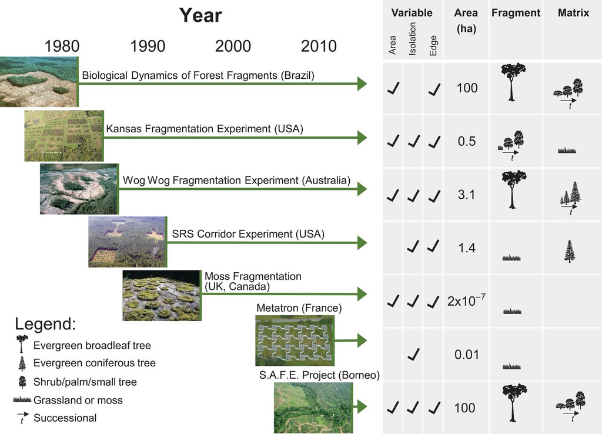

Fig. 2 The world’s ongoing fragmentation experiments.

All experiments have been running continuously since the time indicated by the start of the associated arrow (with the exception of the moss fragmentation experiment, which represents a series of studies over nearly two decades). The variables under study in each experiment are checked. The area is that of the experiment’s largest fragments. Icons under “Fragment” and “Matrix” indicate the dominant community and its relative height, with multiple trees representing succession.

These experiments mimic anthropogenic fragmentation; they are whole-ecosystem manipulations in which all species and processes experienced the same treatment (*24*). Emergent responses thus reflect the multiple direct and indirect effects of interacting species and processes. Further, because experimentally fragmented ecosystems are open to fluxes of individuals and resources, fragmentation effects can manifest across multiple levels of ecological organization (Fig. 3). Long-term experiments have the power to detect lagged and/or chronic impacts.

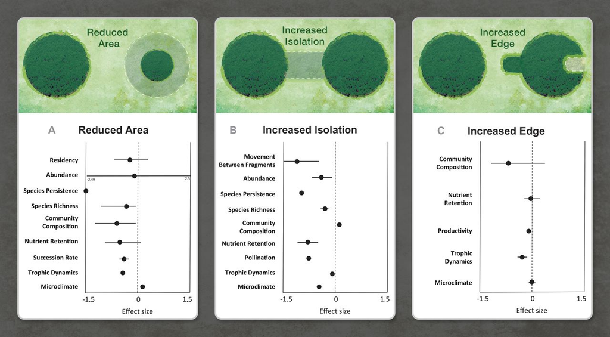

Fig. 3 Fragmentation effects propagate through the whole ecosystem.

(**A** to **C**) For each fragmentation treatment [reduced area in BDFFP, Wog Wog, Kansas (A); increased isolation in SRS and Moss (B); and increased edge in all experiments (C)], we summarize major findings for ecological processes at all levels of ecological organization. Each dot represents the mean effect size [computed as log response ratio: ln(mean in more fragmented treatment/mean in non- or less-fragmented treatment)] for an ecological process. Effect sizes are statistical, such that negative or positive values could represent degrading function. Horizontal bars are the range when a dot is represented by more than one study. Details, including individual effect sizes for each study, are reported in table S1.

The first fragmentation experiments, now more than three decades old, were created to test effects of fragment area on both species persistence and patterns of immigration, reflecting concern in conservation biology about the role of fragmentation in reducing population sizes below viable levels (*25*) (Fig. 2). Subsequent experiments, created two decades ago, shifted focus to modifying habitat isolation, reflecting recognition of the potential to mitigate negative effects of fragmentation by recreating habitat—specifically with corridors—to increase connectivity among fragments (*26*) (Fig. 2). The newest experiments test emerging questions about potentially deleterious synergies between fragmentation and global changes in climate and land use (Fig. 2).

We synthesized results available 31 January 2014 for all studies within these experiments that were conducted in all treatments and replicates, and tested fragmentation effects on dispersal, abundance, extinction, species richness, community composition, and ecosystem functioning. We first calculated effect sizes of fragmentation as log response ratios (Fig. 3). Data from 76 different studies across the five longest-running experiments were drawn from published and unpublished sources (table S1). We synthesized results according to three fragmentation treatments: reduced fragment area [the focus of Biological Dynamics of Forest Fragments Project (BDFFP), Wog Wog, and Kansas; see Fig. 2 for identifiers of experiments], increased fragment isolation [Savannah River Site (SRS) and Moss], and increased proportion of edge (all experiments). Fragmented treatments were compared directly to non- or less-fragmented habitats that were either larger or connected via structural corridors (table S1).

### Strong, consistent, and accumulating effects of habitat fragmentation

Our synthesis revealed strong and consistent responses of organisms and ecosystem processes to fragmentation arising from decreased fragment area, increased isolation, and the creation of habitat edges (Fig. 3).

Community and ecosystem responses emerge from observed responses at the level of populations. Reduced area decreased animal residency within fragments, and increased isolation reduced movement among fragments, thus reducing fragment recolonization after local extinction (Fig. 3, A and B). Reduced fragment area and increased fragment isolation generally reduced abundance of birds, mammals, insects, and plants (Fig. 3, A and B). This overall pattern emerged despite complex patterns of increases or declines in abundance of individual species (Fig. 3A) with various proximate causes such as release from competition or predation, shifts in disturbance regimes, or alteration of abiotic factors (*14*, *27*–*29*). Reduced area, increased isolation, and increased proportion of edge habitat reduced seed predation and herbivory, whereas increased proportion of edge caused higher fledgling predation that had the effect of reducing bird fecundity (represented together as trophic dynamics in Fig. 3, A to C). Perhaps because of reduced movement and abundance, the ability of species to persist was lower in smaller and more isolated fragments (Fig. 3, A and B).

As predicted by theory (*6*, *30*, *31*), fragmentation strongly reduced species richness of plants and animals across experiments (Fig. 3, A and B), often changing the composition of entire communities (Fig. 3, A to C). In tropical forests, reduced fragment size and increased proportion of edge habitat caused shifts in the physical environment that led to the loss of large and old trees in favor of pioneer trees (Fig. 3, A and C), with subsequent impacts on the community composition of insects (*32*). In grasslands, fragment size also affected succession rate, such that increased light penetration and altered seed pools in smaller fragments impeded the rate of ecological succession relative to that of larger fragments (*33*) (Fig. 3A).

Consistently, all aspects of fragmentation—reduced fragment area, increased isolation, and increased edge—had degrading effects on a disparate set of core ecosystem functions. Degraded functions included reduced carbon and nitrogen retention (Fig. 3, A to C), productivity (Fig. 3C), and pollination (Fig. 3B).

In summary, across experiments spanning numerous studies and ecosystems, fragmentation consistently degraded ecosystems, reducing species persistence, species richness, nutrient retention, trophic dynamics, and, in more isolated fragments, movement.

### Long-term consequences of fragmentation

To synthesize all time series of species richness and ecosystem functioning gathered across experiments, we measured effects of fragmentation over the course of each study. The effect of fragmentation was calculated over time as the proportional change in fragmented relative to non- or less-fragmented treatments (Fig. 4).

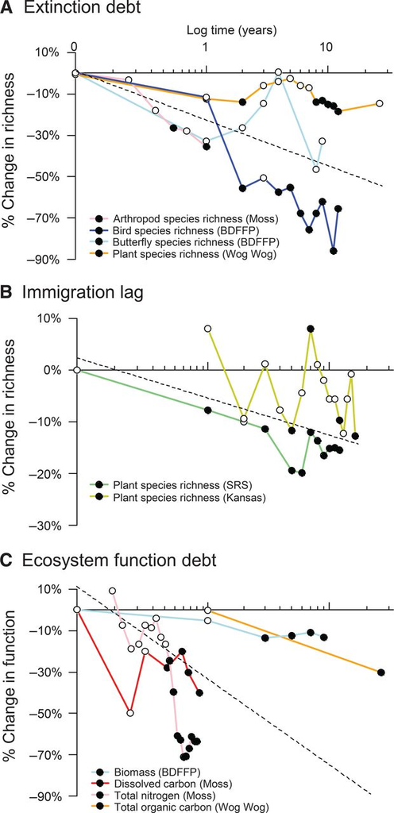

Fig. 4 Delayed effects of fragmentation on ecosystem degradation.

(**A**) The extinction debt represents a delayed loss of species due to fragmentation. (**B**) The immigration lag represents differences in species richness caused by smaller fragment area or increased isolation during fragment succession. (**C**) The ecosystem function debt represents delayed changes in ecosystem function due to reduced fragment size or increased isolation. Percent loss is calculated as proportional change in fragmented treatments [for example, (no. of species in fragment − no. of species in control)/(no. of species in control) × 100]. Fragments and controls were either the same area before and after fragmentation, fragments compared to unfragmented controls, or small compared to large fragments. Filled symbols indicate times when fragmentation effects became significant, as determined by the original studies (see table S2). Mean slopes (dashed lines) were estimated using linear mixed (random slopes) models. Mean slope estimates (mean and SE) were as follows: (A) −0.22935 (0.07529); (B) −0.06519 (0.03495); (C) −0.38568 (0.16010).

Second, we observed that reduced richness was coincident with an “immigration lag” (*37*), whereby small or isolated fragments are slower to accumulate species during community assembly (*33*, *38*) (Fig. 4B). Immigration lags were observed in experiments conducted in successional systems that were initiated by creating new habitat fragments, rather than by fragmenting existing habitats. After more than a decade, immigration lags resulted in 5% fewer species after 1 year, and 15% fewer species after 10 years in small or isolated fragments compared to large or connected fragments (Fig. 4B).

Third, we observed an ecosystem function debt caused by fragmentation (*39*) in forest and moss fragments (Fig. 4C). An ecosystem function debt is manifest both as delayed changes in nutrient cycling and as changes to plant and consumer biomass. Loss of function amounted to 30% after 1 year, rising to 80% after a decade in small and isolated fragments when compared to larger and more connected fragments (Fig. 4C). Functional debts can result from biodiversity loss, as when loss of nutrients and reduction in decomposition are caused by simplification of food webs. Alternatively, the impact is exhibited through pathways whereby fragmentation changes biotic (for example, tree density in successional systems) or abiotic conditions (for example, light regimes or humidity) in ways that alter and potentially impair ecosystem function [for example, biomass collapse in fragments; Figs. 3 and 4; altered nitrogen and carbon soil dynamics (*40*)].

### A new understanding of the effects of fragmentation

By testing existing theory, experiments play a pivotal role in advancing ideas and developing new theory. We draw on experimental evidence to highlight two ways that the understanding of fragmentation has been enriched by the interplay between long-term experiments and development of theory.

First, island biogeography (*6*) was among the earliest theories to predict extinction and immigration rates and patterns of species richness in isolated biotas, which were later used to predict the effects of fragmentation on these variables. Experiments in continental settings tested the theory and gave rise to fresh perspectives. For example, islands are surrounded by sea, a thoroughly inimical matrix for island-dwelling species. Habitat islands, or fragments, are surrounded by a matrix that may not be so unsuitable for some species. In terms of all of the ecological variables studied in our long-term experiments, our results support the conclusion that ecological dynamics in human-modified fragments are a stark contrast to the dynamics in intact habitats that remain. Observational studies that have devoted more detailed consideration to the countryside within which fragments are embedded explain the diversity of ecological responses in remaining fragments (*41*). At the same time as experiments supported the core predictions of classical theories about effects of fragment size and isolation (Figs. 3 and 4), they spurred and tested new theories such as metacommunity theory (*42*) to account for variation in connectivity and habitat quality within and between fragments (*33*, *43*–*45*), spatial dynamics (*14*, *46*), and spatially varying interspecific interactions (*47*).

Second, experiments have demonstrated that the effects of fragmentation are mediated by variation in traits across species. More realistic predictions of community responses to fragmentation emerged after explicit consideration of species traits such as rarity and trophic levels (*48*, *49*), dispersal mode (*50*–*52*), reproductive mode and life span (*29*, *53*), diet (*54*), and movement behavior (*55*, *56*). Increasingly, the simple theoretical prediction that fragmentation reduces species richness is being modified to account for species identity through models that focus on how species vary in their traits (*4*, *21*, *36*, *48*, *57*, *58*). Consideration of traits may help to interpret variation around the overarching pattern that fragmentation consistently reduces species richness across many species and biomes (Figs. 3 and 4).

## A NEW GENERATION OF FRAGMENTATION EXPERIMENTS

New foci are emerging for studying ecosystem fragmentation, including (i) synergies between fragmentation and global changes, (ii) eco-evolutionary responses of species to fragmentation, and (iii) ecological responses to fragmentation in production landscapes—that is, ecosystems whose services are under extreme appropriation by humans (*59*).

First, conclusions from experiments thus far are likely to have been conservative because impacts from other environmental changes have been mostly excluded. Most forms of global change known to reduce population sizes and biodiversity will be exacerbated by fragmentation (*58*, *60*), including climate change (*61*), invasive species (*62*, *63*), hunting (*64*), pollution [including light, noise, and chemicals (*65*)], and altered disturbance regimes (*66*).

More complex experiments with unparalleled control and capacity to simultaneously manipulate fragmentation and other global changes are now under way (*53*). The Metatron, created in 2011 in southern France (*67*), enables ecologists to assess effects of variation in temperature and other abiotic factors in addition to habitat isolation. The SAFE Project is being created in the rainforest of Borneo (*68*) and will embed a fragmentation experiment within a production agricultural plantation in which poaching will occur. Other synergies should be investigated experimentally, including the interaction between fragmentation and hunting, fire, infectious disease outbreaks, or nitrogen deposition. Within these experiments, fragmentation and loss of habitat can then be varied independently.

Second, current experiments have stopped short of examining how fragmentation drives evolution through genetic bottlenecks, ecological traps, changing patterns of selection, inbreeding, drift, and gene flow (*69*–*72*). Extensive fragmentation has occurred over many years, and in some regions over millennia (*11*). Changes caused by fragmentation undoubtedly lead to altered patterns of selection and trait evolution. Evolutionary responses to fragmentation have already been suggested (*73*, *74*), and it is likely that such changes will, in turn, feed back to influence population persistence and ecosystem resilience in fragmented landscapes. Linking long-term experiments with the tools of landscape genetics (*75*) may provide powerful insights into the evolutionary dynamics of species inhabiting fragmented landscapes.

Third, new experiments should address the management of natural habitats in production landscapes by monitoring vegetation, networks of interacting species, and ecosystem services at ecologically relevant spatial and temporal scales (*76*–*78*). Some ecosystem services have global consequences, for example, local carbon sequestration affects global atmospheric CO<sub>2</sub>. However, in many cases the benefits obtained by people depend on their proximity to habitat fragments (*79*). For example, crop pollination and biological pest control from natural areas adjacent to farms are made available by the very process of habitat fragmentation, bringing people and agriculture closer to those services. Yet, further fragmentation reduces access to many services and ultimately may push landscapes past tipping points, beyond which essential ecosystem services are not merely diminished but lost completely (*80*). This complex relationship creates a double-edged sword, for which locally optimal levels and arrangements of habitat must be sought. New fragmentation experiments should consider how multiple fragments in a landscape interact, creating an ecological network in which the collective benefit of ecosystem services may be greater than the sum of services provided by individual fragments (*81*, *82*). Experimental inferences may then be tested beyond their spatiotemporal domains and, if successful, extrapolated across scales. Such research will be aided by satellite monitoring of ecosystems and human land use across the globe. The most powerful research programs will integrate experiments, observational studies, air- and space-borne imaging, and modeling.

## CONCLUSIONS

Fragmentation experiments—some of the largest and longest-running experiments in ecology—provide clear evidence of strong and typically degrading impacts of habitat fragmentation on biodiversity and ecological processes. The findings of these experiments extend to a large fraction of the terrestrial surface of the Earth. Much of the Earth’s remaining forest fragments are less than 10 ha in area, and half of the world’s forest is within 500 m of the forest edge—areas and distances matched to existing long-term experiments (Figs. 1 and 2) from which consistent effects of fragmentation have emerged (Figs. 3 and 4).

Reduced fragment area, increased isolation, and increased edge initiate changes that percolate through ecosystems (Fig. 3). Fragmentation has the capacity to generate persistent, deleterious, and often unpredicted outcomes, including surprising surges in abundance of some species and the pattern that long temporal scales are required to discern many strong system responses. In light of these conclusions and ongoing debates, we suggest that fragmentation’s consistency, pervasiveness, and long-term degrading effect on biodiversity and ecosystem function have not been fully appreciated (*9*).

Without gains in yield and efficiency of agricultural systems (*83*), the expansion of human populations will inevitably continue to reduce and fragment natural areas. The area of Earth’s land surface devoted to cropland already occupies 1.53 billion hectares (*83*) and may expand 18% by the middle of this century (*84*), and the area committed to urban centers is predicted to triple to 0.18 billion hectares by 2030 (*85*). The capacity of the surviving forests and other natural habitats to sustain biodiversity and ecosystem services will hinge upon the total amount and quality of habitat left in fragments, their degree of connectivity, and how they are affected by other human-induced perturbations such as climate change and invasive species. Long-term experiments will be even more needed to appreciate, explain, and predict long-term effects. New efforts should work in concert, coordinating a network of experiments across ecosystems and spatial extents.

The effects of current fragmentation will continue to emerge for decades. Extinction debts are likely to come due, although the counteracting immigration debts may never fully be paid. Indeed, the experiments here reveal ongoing losses of biodiversity and ecosystem functioning two decades or longer after fragmentation occurred. Understanding the relationship between transient and long-term dynamics is a substantial challenge that ecologists must tackle, and fragmentation experiments will be central for relating observation to theory.

Experimental results to date show that the effects of fragmentation are strong and markedly consistent across a diverse array of terrestrial systems on five continents. Increasingly, these effects will march in concert with other global changes. New experiments should be coupled with emerging technologies, landscape genetics, and detailed imagery of our planet, and should be coordinated with current ecological theory to understand more deeply the coupled dynamics of ecological and social systems. These insights will be increasingly critical for those responsible for managing and prioritizing areas for preservation and ecological restoration in fragmented landscapes.

## Acknowledgments

For comments, we thank R. Dunn, P. Ehrlich, L. Frishkoff, F. Gould, A. Leidner, C. Mendenhall, A. Tal, J. Watling, and the Fukami and Peay labs at Stanford. For symbols in figures, we thank the Integration and Application Network, University of Maryland Center for Environmental Science. **Funding:** R.M.E. is supported by ERC (European Research Council) Project number 281986. A.G. is supported by the Natural Sciences and Engineering Research Council, the Canada Research Chair program, and the Quebec Centre for Biodiversity Science. C.N.J. was supported by the Brazilian agency CAPES through the Ciência Sem Fronteiras program. R.D.H. thanks the University of Florida Foundation. J.C. is supported by the labex TULIP and the ANR Infrastructure grant AnaEE-France. Global forest cover data and analysis were provided under support from the NASA Making Earth System Data Records for Use in Research Environments (MEaSUREs; NNH06ZDA001N) and Land Cover and Land Use Change (NNH07ZDA001N-LCLUC) programs. For long-term support of experiments, we thank the Andrew W. Mellon Foundation (BDFFP); the Kansas Biological Survey and National Science Foundation (NSF) (DEB 01-08302 and DEB-0950100; Kansas Experiment); NSF and U.S. Department of Agriculture Forest Service–Savannah River (SRS Corridor Experiment); NSF DEB 0841892 and Environment and Heritage NSW, Forestry Corporation NSW, and CSIRO Ecosystem Sciences (Wog Wog); and the Sime Darby Foundation (SAFE).

## Supplementary Material

### Summary

Materials and Methods

Fig. S1. Map of the BDFFP experiment and location within Brazil.

Fig. S2. Map of the Kansas fragmentation experiment.

Fig. S3. Map of the Wog Wog experiment and location within Australia.

Fig. S4. Map of the SRS experiment showing locations of the eight blocks in the second SRS Corridor Experiment within the SRS, South Carolina, USA.

Fig. S5. Design of the Moss experiment.

Fig. S6. Design of the Metatron experiment with 48 enclosed fragments and adjoining enclosed corridors.

Fig. S7. Map of the SAFE experiment and location within Borneo [after Ewers *et al*. (*68*)].

Table S1. Metadata for Fig. 3 in the main text.

Table S2. Metadata for Fig. 4 in the main text.

### Resources

File (e1500052_sm.pdf)

[Download](https://www.science.org/doi/suppl/10.1126/sciadv.1500052/suppl_file/e1500052_sm.pdf)

## REFERENCES AND NOTES

1

H. M. Pereira, P. W. Leadley, V. Proenca, R. Alkemade, J. P. W. Scharlemann, J. F. Fernandez-Manjarres, M. B. Araujo, P. Balvanera, R. Biggs, W. W. L. Cheung, L. Chini, H. D. Cooper, E. L. Gilman, S. Guenette, G. C. Hurtt, H. P. Huntington, G. M. Mace, T. Oberdorff, C. Revenga, P. Rodrigues, R. J. Scholes, U. R. Sumaila, M. Walpole, Scenarios for global biodiversity in the 21st century. *Science* **330**, 1496–1501 (2010).

Go to reference

[Crossref](https://doi.org/10.1126/science.1196624)

[PubMed](https://www.ncbi.nlm.nih.gov/pubmed/20978282)

ISI

Google Scholar

[figure not shown]

2

M. R. W. Rands, W. M. Adams, L. Bennun, S. H. M. Butchart, A. Clements, D. Coomes, A. Entwistle, I. Hodge, V. Kapos, J. P. W. Scharlemann, W. J. Sutherland, B. Vira, Biodiversity conservation: Challenges beyond 2010. *Science* **329**, 1298–1303 (2010).

Go to reference

[Crossref](https://doi.org/10.1126/science.1189138)

Google Scholar

[figure not shown]

3

D. B. Lindenmayer, J. Fischer, *Habitat Fragmentation and Landscape Change: An Ecological and Conservation Synthesis* (Island Press, Washington, DC, 2006).

Go to reference

[Google Scholar](https://scholar.google.com/scholar?q=D.+B.+Lindenmayer%2C+J.+Fischer%2C+Habitat+Fragmentation+and+Landscape+Change%3A+An+Ecological+and+Conservation+Synthesis+%28Island+Press%2C+Washington%2C+DC%2C+2006%29.)

4

R. K. Didham, V. Kapos, R. M. Ewers, Rethinking the conceptual foundations of habitat fragmentation research. *Oikos* **121**, 161–170 (2012).

Google Scholar

[figure not shown]

5

L. Fahrig, Rethinking patch size and isolation effects: The habitat amount hypothesis. *J. Biogeogr.* **40**, 1649–1663 (2013).

Go to reference

[Google Scholar](https://scholar.google.com/scholar_lookup?title=Rethinking+patch+size+and+isolation+effects%3A+The+habitat+amount+hypothesis&author=L.+Fahrig&publication_year=2013&pages=1649-1663)

[figure not shown]

6

R. H. MacArthur, E. O. Wilson, *The Theory of Island Biogeography* (Princeton University Press, Princeton, NJ, 1967).

[Google Scholar](https://scholar.google.com/scholar?q=R.+H.+MacArthur%2C+E.+O.+Wilson%2C+The+Theory+of+Island+Biogeography+%28Princeton+University+Press%2C+Princeton%2C+NJ%2C+1967%29.)

7

L. Fahrig, Effects of habitat fragmentation on biodiversity. *Annu. Rev. Ecol. Evol. Syst.* **34**, 487–515 (2003).

[Crossref](https://doi.org/10.1146/annurev.ecolsys.34.011802.132419)

ISI

[Google Scholar](https://scholar.google.com/scholar_lookup?title=Effects+of+habitat+fragmentation+on+biodiversity&author=L.+Fahrig&publication_year=2003&pages=487-515&doi=10.1146%2Fannurev.ecolsys.34.011802.132419)

[figure not shown]

8

S. K. Collinge, *The Ecology of Fragmented Landscapes* (The Johns Hopkins University Press, Baltimore, MD, 2009).

Go to reference

[Google Scholar](https://scholar.google.com/scholar?q=S.+K.+Collinge%2C+The+Ecology+of+Fragmented+Landscapes+%28The+Johns+Hopkins+University+Press%2C+Baltimore%2C+MD%2C+2009%29.)

9

I. Ibanez, D. S. W. Katz, D. Peltier, S. M. Wolf, B. T. C. Barrie, Assessing the integrated effects of landscape fragmentation on plants and plant communities: The challenge of multiprocess–multiresponse dynamics. *J. Ecol.* **102**, 882–895 (2014).

Google Scholar

[figure not shown]

10

M. C. Hansen, P. V. Potapov, R. Moore, M. Hancher, S. A. Turubanova, A. Tyukavina, D. Thau, S. V. Stehman, S. J. Goetz, T. R. Loveland, A. Kommareddy, A. Egorov, L. Chini, C. O. Justice, J. R. G. Townshend, High-resolution global maps of 21st-century forest cover change. *Science* **342**, 850–853 (2013).

[Crossref](https://doi.org/10.1126/science.1244693)

[PubMed](https://www.ncbi.nlm.nih.gov/pubmed/24233722)

ISI

Google Scholar

[figure not shown]

11

M. Williams, *Deforesting the Earth*: *From Prehistory to Global Crisis* (University of Chicago Press, Chicago, 2003).

[Google Scholar](https://scholar.google.com/scholar?q=M.+Williams%2C+Deforesting+the+Earth%3A+From+Prehistory+to+Global+Crisis+%28University+of+Chicago+Press%2C+Chicago%2C+2003%29.)

12

D. Skole, C. Tucker, Tropical deforestation and habitat fragmentation in the Amazon: Satellite data from 1978 to 1988. *Science* **260**, 1905–1910 (1993).

Go to reference

[Crossref](https://doi.org/10.1126/science.260.5116.1905)

Google Scholar

[figure not shown]

13

J. O. Sexton, X. P. Song, M. Feng, P. Noojipady, A. Anand, C. Q. Huang, D. H. Kim, K. M. Collins, S. Channan, C. DiMiceli, J. R. Townshend, Global, 30-m resolution continuous fields of tree cover: Landsat-based rescaling of MODIS vegetation continuous fields with lidar-based estimates of error. *Int. J. Digital Earth* **6**, 427–448 (2013).

Go to reference

Google Scholar

[figure not shown]

14

W. F. Laurance, T. E. Lovejoy, H. L. Vasconcelos, E. M. Bruna, R. K. Didham, P. C. Stouffer, C. Gascon, R. O. Bierregaard, S. G. Laurance, E. Sampaio, Ecosystem decay of Amazonian forest fragments: A 22-year investigation. *Conserv. Biol.* **16**, 605–618 (2002).

[Crossref](https://doi.org/10.1046/j.1523-1739.2002.01025.x)

ISI

Google Scholar

[figure not shown]

15

E. N. Broadbent, G. P. Asner, M. Keller, D. E. Knapp, P. J. C. Oliveira, J. N. Silva, Forest fragmentation and edge effects from deforestation and selective logging in the Brazilian Amazon. *Biol. Conserv.* **141**, 1745–1757 (2008).

Go to reference

[Crossref](https://doi.org/10.1016/j.biocon.2008.04.024)

ISI

Google Scholar

[figure not shown]

16

M. C. Ribeiro, J. P. Metzger, A. C. Martensen, F. J. Ponzoni, M. M. Hirota, The Brazilian Atlantic Forest: How much is left, and how is the remaining forest distributed? Implications for conservation. *Biol. Conserv.* **142**, 1141–1153 (2009).

Go to reference

[Crossref](https://doi.org/10.1016/j.biocon.2009.02.021)

ISI

Google Scholar

[figure not shown]

17

T. P. Hughes, D. R. Bellwood, C. Folke, R. S. Steneck, J. Wilson, New paradigms for supporting the resilience of marine ecosystems. *Trends Ecol. Evol.* **20**, 380–386 (2005).

Go to reference

Google Scholar

[figure not shown]

18

T. Ricketts, E. Dinerstein, D. Olson, C. Loucks, W. Eichbaum, K. Kavanagh, P. Hedao, P. Hurley, K. Carney, R. Abell, S. Walters, *A Conservation Assessment of the Terrestrial Ecoregions of North America* (Island Press, Washington, DC, 1999).

Go to reference

Google Scholar

19

R. P. White, S. Murray, M. Rohweder, *Grassland Ecosystems* (World Resources Institute, Washington, DC, 2000).

Go to reference

[Google Scholar](https://scholar.google.com/scholar?q=R.+P.+White%2C+S.+Murray%2C+M.+Rohweder%2C+Grassland+Ecosystems+%28World+Resources+Institute%2C+Washington%2C+DC%2C+2000%29.)

20

K. McGarigal, S. A. Cushman, Comparative evaluation of experimental approaches to the study of habitat fragmentation effects. *Ecol. Appl.* **12**, 335–345 (2002).

Go to reference

Google Scholar

[figure not shown]

21

H. M. Martinson, W. F. Fagan, Trophic disruption: A meta-analysis of how habitat fragmentation affects resource consumption in terrestrial arthropod systems. *Ecol. Lett.* **17**, 1178–1189 (2014).

Google Scholar

[figure not shown]

22

J. I. Watling, M. A. Donnelly, Fragments as islands: A synthesis of faunal responses to habitat patchiness. *Conserv. Biol.* **20**, 1016–1025 (2006).

Go to reference

[Google Scholar](https://scholar.google.com/scholar_lookup?title=Fragments+as+islands%3A+A+synthesis+of+faunal+responses+to+habitat+patchiness&author=J.+I.+Watling&author=M.+A.+Donnelly&publication_year=2006&pages=1016-1025)

[figure not shown]

23

K. M. Flinn, M. Vellend, P. L. Marks, Environmental causes and consequences of forest clearance and agricultural abandonment in central New York, USA. *J. Biogeogr.* **32**, 439–452 (2005).

Go to reference

Google Scholar

[figure not shown]

24

D. A. Saunders, R. J. Hobbs, C. R. Margules, Biological consequences of ecosystem fragmentation: A review. *Conserv. Biol.* **5**, 18–32 (1991).

Go to reference

[Google Scholar](https://scholar.google.com/scholar_lookup?title=Biological+consequences+of+ecosystem+fragmentation%3A+A+review&author=D.+A.+Saunders&author=R.+J.+Hobbs&author=C.+R.+Margules&publication_year=1991&pages=18-32)

[figure not shown]

25

M. E. Soulé, *Viable Populations for Conservation* (Cambridge University Press, Cambridge, UK, 1987).

Go to reference

[Google Scholar](https://scholar.google.com/scholar?q=M.+E.+Soul%C3%A9%2C+Viable+Populations+for+Conservation+%28Cambridge+University+Press%2C+Cambridge%2C+UK%2C+1987%29.)

26

E. O. Wilson, E. O. Willis, in *Ecology and Evolution of Communities*, M. L. Cody, J. M. Diamond, Eds. (The Belknap Press, Cambridge, MA, 1975), pp. 522–534.

Go to reference

Google Scholar

27

H. L. Vasconcelos, E. M. Bruna, Arthropod responses to the experimental isolation of Amazonian forest fragments. *Zoologia* **29**, 515–530 (2012).

Go to reference

[Google Scholar](https://scholar.google.com/scholar_lookup?title=Arthropod+responses+to+the+experimental+isolation+of+Amazonian+forest+fragments&author=H.+L.+Vasconcelos&author=E.+M.+Bruna&publication_year=2012&pages=515-530)

[figure not shown]

28

N. M. Haddad, L. A. Brudvig, E. I. Damschen, D. M. Evans, B. L. Johnson, D. J. Levey, J. L. Orrock, J. Resasco, L. L. Sullivan, J. J. Tewksbury, S. A. Wagner, A. J. Weldon, Potential negative ecological effects of corridors. *Conserv. Biol.* **28**, 1178–1187 (2014).

Google Scholar

[figure not shown]

29

C. D. Collins, R. D. Holt, B. L. Foster, Patch size effects on plant species decline in an experimentally fragmented landscape. *Ecology* **90**, 2577–2588 (2009).

Google Scholar

[figure not shown]

30

D. Tilman, R. M. May, C. L. Lehman, M. A. Nowak, Habitat destruction and the extinction debt. *Nature* **371**, 65–66 (1994).

[Crossref](https://doi.org/10.1038/371065a0)

ISI

Google Scholar

[figure not shown]

31

I. Hanski, A. Moilanen, M. Gyllenberg, Minimum viable metapopulation size. *Am. Nat.* **147**, 527–541 (1996).

Go to reference

[Google Scholar](https://scholar.google.com/scholar_lookup?title=Minimum+viable+metapopulation+size&author=I.+Hanski&author=A.+Moilanen&author=M.+Gyllenberg&publication_year=1996&pages=527-541)

[figure not shown]

32

W. F. Laurance, P. Delamonica, S. G. Laurance, H. L. Vasconcelos, T. E. Lovejoy, Conservation: Rainforest fragmentation kills big trees. *Nature* **404**, 836 (2000).

Go to reference

Google Scholar

[figure not shown]

33

W. M. Cook, J. Yao, B. L. Foster, R. D. Holt, L. B. Patrick, Secondary succession in an experimentally fragmented landscape: Community patterns across space and time. *Ecology* **86**, 1267–1279 (2005).

Google Scholar

[figure not shown]

34

A. Gonzalez, Community relaxation in fragmented landscapes: The relation between species richness, area and age. *Ecol. Lett.* **3**, 441–448 (2000).

Go to reference

[Google Scholar](https://scholar.google.com/scholar_lookup?title=Community+relaxation+in+fragmented+landscapes%3A+The+relation+between+species+richness%2C+area+and+age&author=A.+Gonzalez&publication_year=2000&pages=441-448)

[figure not shown]

35

G. Ferraz, G. J. Russell, P. C. Stouffer, R. O. Bierregaard, S. L. Pimm, T. E. Lovejoy, Rates of species loss from Amazonian forest fragments. *Proc. Natl. Acad. Sci. U.S.A.* **100**, 14069–14073 (2003).

Go to reference

Google Scholar

[figure not shown]

36

J. L. Orrock, J. I. Watling, Local community size mediates ecological drift and competition in metacommunities. *Proc. Biol. Sci.* **277**, 2185–2191 (2010).

[Google Scholar](https://scholar.google.com/scholar_lookup?title=Local+community+size+mediates+ecological+drift+and+competition+in+metacommunities&author=J.+L.+Orrock&author=J.+I.+Watling&publication_year=2010&pages=2185-2191)

[figure not shown]

37

S. T. Jackson, D. F. Sax, Balancing biodiversity in a changing environment: Extinction debt, immigration credit and species turnover. *Trends Ecol. Evol.* **25**, 153–160 (2010).

Go to reference

Google Scholar

[figure not shown]

38

J. Clobert, J. F. Le Galliard, J. Cote, S. Meylan, M. Massot, Informed dispersal, heterogeneity in animal dispersal syndromes and the dynamics of spatially structured populations. *Ecol. Lett.* **12**, 197–209 (2009).

Go to reference

Google Scholar

[figure not shown]

39

P. Staddon, Z. Lindo, P. D. Crittenden, F. Gilbert, A. Gonzalez, Connectivity, non-random extinction and ecosystem function in experimental metacommunities. *Ecol. Lett.* **13**, 543–552 (2010).

Go to reference

Google Scholar

[figure not shown]

40

S. A. Billings, E. A. Gaydess, Soil nitrogen and carbon dynamics in a fragmented landscape experiencing forest succession. *Landsc. Ecol.* **23**, 581–593 (2008).

Go to reference

Google Scholar

[figure not shown]

41

C. D. Mendenhall, D. S. Karp, C. F. J. Meyer, E. A. Hadly, G. C. Daily, Predicting biodiversity change and averting collapse in agricultural landscapes. *Nature* **509**, 213−217 (2014).

Go to reference

[Crossref](https://doi.org/10.1038/nature13139)

[PubMed](https://www.ncbi.nlm.nih.gov/pubmed/24739971)

ISI

Google Scholar

[figure not shown]

42

A. Gonzalez, J. H. Lawton, F. S. Gilbert, T. M. Blackburn, I. Evans-Freke, Metapopulation dynamics, abundance, and distribution in a microecosystem. *Science* **281**, 2045–2047 (1998).

Go to reference

[Crossref](https://doi.org/10.1126/science.281.5385.2045)

Google Scholar

[figure not shown]

43

H. M. Alexander, B. L. Foster, F. Ballantyne, C. D. Collins, J. Antonovics, R. D. Holt, Metapopulations and metacommunities: Combining spatial and temporal perspectives in plant ecology. *J. Ecol.* **100**, 88–103 (2012).

Go to reference

Google Scholar

[figure not shown]

44

C. R. Margules, The Wog Wog habitat fragmentation experiment. *Environ. Conserv.* **19**, 316–325 (1992).

[Google Scholar](https://scholar.google.com/scholar_lookup?title=The+Wog+Wog+habitat+fragmentation+experiment&author=C.+R.+Margules&publication_year=1992&pages=316-325)

[figure not shown]

45

E. I. Damschen, L. A. Brudvig, Landscape connectivity strengthens local–regional richness relationships in successional plant communities. *Ecology* **93**, 704–710 (2012).

Go to reference

Google Scholar

[figure not shown]

46

W. M. Cook, K. T. Lane, B. L. Foster, R. D. Holt, Island theory, matrix effects and species richness patterns in habitat fragments. *Ecol. Lett.* **5**, 619–623 (2002).

Go to reference

Google Scholar

[figure not shown]

47

K. F. Davies, B. A. Melbourne, C. R. Margules, Effects of within- and between-patch processes on community dynamics in a fragmentation experiment. *Ecology* **82**, 1830–1846 (2001).

Go to reference

Google Scholar

[figure not shown]

48

K. F. Davies, C. R. Margules, K. F. Lawrence, Which traits of species predict population declines in experimental forest fragments? *Ecology* **81**, 1450–1461 (2000).

Google Scholar

[figure not shown]

49

K. F. Davies, C. R. Margules, J. F. Lawrence, A synergistic effect puts rare, specialized species at greater risk of extinction. *Ecology* **85**, 265–271 (2004).

Go to reference

Google Scholar

[figure not shown]

50

J. Yao, R. D. Holt, P. M. Rich, W. S. Marshall, Woody plant colonization in an experimentally fragmented landscape. *Ecography* **22**, 715–728 (1999).

Go to reference

Google Scholar

[figure not shown]

51

E. I. Damschen, L. A. Brudvig, N. M. Haddad, D. J. Levey, J. L. Orrock, J. J. Tewksbury, The movement ecology and dynamics of plant communities in fragmented landscapes. *Proc. Natl. Acad. Sci. U.S.A.* **105**, 19078–19083 (2008).

Google Scholar

[figure not shown]

52

L. L. Sullivan, B. L. Johnson, L. A. Brudvig, N. M. Haddad, Can dispersal mode predict corridor effects on plant parasites? *Ecology* **92**, 1559–1564 (2011).

Go to reference

Google Scholar

[figure not shown]

53

Z. Lindo, J. Whiteley, A. Gonzalez, Traits explain community disassembly and trophic contraction following experimental environmental change. *Glob. Chang. Biol.* **18**, 2448–2457 (2012).

Google Scholar

[figure not shown]

54

S. A. Boyle, A. T. Smith, Can landscape and species characteristics predict primate presence in forest fragments in the Brazilian Amazon? *Biol. Conserv.* **143**, 1134–1143 (2010).

Go to reference

Google Scholar

[figure not shown]

55

J. E. Diffendorfer, M. S. Gaines, R. D. Holt, Habitat fragmentation and movements of three small mammals (Sigmodon, Microtus, and Peromyscus). *Ecology* **76**, 827–839 (1995).

Go to reference

Google Scholar

[figure not shown]

56

K. S. Van Houtan, S. L. Pimm, J. M. Halley, R. O. Bierregaard Jr, T. E. Lovejoy, Dispersal of Amazonian birds in continuous and fragmented forest. *Ecol. Lett.* **10**, 219–229 (2007).

Go to reference

Google Scholar

[figure not shown]

57

I. Hanski, Extinction debt at different spatial scales. *Anim. Conserv.* **16**, 12–13 (2013).

Go to reference

[Google Scholar](https://scholar.google.com/scholar_lookup?title=Extinction+debt+at+different+spatial+scales&author=I.+Hanski&publication_year=2013&pages=12-13)

[figure not shown]

58

R. Dirzo, H. S. Young, M. Galetti, G. Ceballos, N. J. B. Isaac, B. Collen, Defaunation in the Anthropocene. *Science* **345**, 401–406 (2014).

[Crossref](https://doi.org/10.1126/science.1251817)

[PubMed](https://www.ncbi.nlm.nih.gov/pubmed/25061202)

ISI

Google Scholar

[figure not shown]

59

C. Kueffer, C. N. Kaiser-Bunbury, Reconciling conflicting perspectives for biodiversity conservation in the Anthropocene. *Front. Ecol. Environ.* **12**, 131–137 (2014).

Go to reference

Google Scholar

[figure not shown]

60

W. F. Laurance, D. C. Useche, Environmental synergisms and extinctions of tropical species. *Conserv. Biol.* **23**, 1427–1437 (2009).

Go to reference

[Google Scholar](https://scholar.google.com/scholar_lookup?title=Environmental+synergisms+and+extinctions+of+tropical+species&author=W.+F.+Laurance&author=D.+C.+Useche&publication_year=2009&pages=1427-1437)

[figure not shown]

61

M. Krosby, J. Tewksbury, N. M. Haddad, J. Hoekstra, Ecological connectivity for a changing climate. *Conserv. Biol.* **24**, 1686–1689 (2010).

Go to reference

[Crossref](https://doi.org/10.1111/j.1523-1739.2010.01585.x)

[PubMed](https://www.ncbi.nlm.nih.gov/pubmed/20961330)

ISI

Google Scholar

[figure not shown]

62

R. K. Didham, J. M. Tylianakis, N. J. Gemmell, T. A. Rand, R. M. Ewers, Interactive effects of habitat modification and species invasion on native species decline. *Trends Ecol. Evol.* **22**, 489–496 (2007).

Go to reference

Google Scholar

[figure not shown]

63

L. Gibson, A. J. Lynam, C. J. A. Bradshaw, F. L. He, D. P. Bickford, D. S. Woodruff, S. Bumrungsri, W. F. Laurance, Near-complete extinction of native small mammal fauna 25 years after forest fragmentation. *Science* **341**, 1508–1510 (2013).

Go to reference

[Crossref](https://doi.org/10.1126/science.1240495)

Google Scholar

[figure not shown]

64

C. A. Peres, Synergistic effects of subsistence hunting and habitat fragmentation on Amazonian forest vertebrates. *Conserv. Biol.* **15**, 1490–1505 (2001).

Go to reference

[Google Scholar](https://scholar.google.com/scholar_lookup?title=Synergistic+effects+of+subsistence+hunting+and+habitat+fragmentation+on+Amazonian+forest+vertebrates&author=C.+A.+Peres&publication_year=2001&pages=1490-1505)

[figure not shown]

65

K. J. Gaston, T. W. Davies, J. Bennie, J. Hopkins, Review: Reducing the ecological consequences of night-time light pollution: Options and developments. *J. Appl. Ecol.* **49**, 1256–1266 (2012).

Go to reference

Google Scholar

[figure not shown]

66

M. A. Cochrane, W. F. Laurance, Fire as a large-scale edge effect in Amazonian forests. *J. Trop. Ecol.* **18**, 311–325 (2002).

Go to reference

[Crossref](https://doi.org/10.1017/S0266467402002237)

ISI

Google Scholar

[figure not shown]

67

D. Legrand, O. Guillaume, M. Baguette, J. Cote, A. Trochet, O. Calvez, S. Zajitschek, F. Zajitschek, J. Lecomte, Q. Benard, J. F. Le Galliard, J. Clobert, The Metatron: An experimental system to study dispersal and metaecosystems for terrestrial organisms. *Nat. Methods* **9**, 828−833 (2012).

Go to reference

Google Scholar

[figure not shown]

68

R. M. Ewers, R. K. Didham, L. Fahrig, G. Ferraz, A. Hector, R. D. Holt, V. Kapos, G. Reynolds, W. Sinun, J. L. Snaddon, E. C. Turner, A large-scale forest fragmentation experiment: The Stability of Altered Forest Ecosystems Project. *Philos. Trans. R. Soc. Lond. B Biol. Sci.* **366**, 3292–3302 (2011).

Google Scholar

[figure not shown]

69

A. R. Templeton, K. Shaw, E. Routman, S. K. Davis, The genetic consequences of habitat fragmentation. *Ann. Mo. Bot. Gard.* **77**, 13–27 (1990).

Go to reference

[Google Scholar](https://scholar.google.com/scholar_lookup?title=The+genetic+consequences+of+habitat+fragmentation&author=A.+R.+Templeton&author=K.+Shaw&author=E.+Routman&author=S.+K.+Davis&publication_year=1990&pages=13-27)

[figure not shown]

70

A. Young, T. Boyle, T. Brown, The population genetic consequences of habitat fragmentation for plants. *Trends Ecol. Evol.* **11**, 413–418 (1996).

[Google Scholar](https://scholar.google.com/scholar_lookup?title=The+population+genetic+consequences+of+habitat+fragmentation+for+plants&author=A.+Young&author=T.+Boyle&author=T.+Brown&publication_year=1996&pages=413-418)

[figure not shown]

71

M. S. Gaines, J. E. Diffendorfer, R. H. Tamarin, T. S. Whittam, The effects of habitat fragmentation on the genetic structure of small mammal populations. *J. Hered.* **88**, 294–304 (1997).

Google Scholar

[figure not shown]

72

J. L. Orrock, Conservation corridors affect the fixation of novel alleles. *Conserv. Genet.* **6**, 623–630 (2005).

Go to reference

[Google Scholar](https://scholar.google.com/scholar_lookup?title=Conservation+corridors+affect+the+fixation+of+novel+alleles&author=J.+L.+Orrock&publication_year=2005&pages=623-630)

[figure not shown]

73

T. Merck, H. Van Dyck, B. Karlsson, O. Leimar, The evolution of movements and behaviour at boundaries in different landscapes: A common arena experiment with butterflies. *Proc. Biol. Sci.* **270**, 1815–1821 (2003).

Go to reference

Google Scholar

[figure not shown]

74

S. P. Ripperger, M. Tschapka, E. K. V. Kalko, B. Rodriguez-Herrera, F. Mayer, Life in a mosaic landscape: Anthropogenic habitat fragmentation affects genetic population structure in a frugivorous bat species. *Conserv. Genet.* **14**, 925–934 (2013).

Go to reference

Google Scholar

[figure not shown]

75

S. Manel, R. Holderegger, Ten years of landscape genetics. *Trends Ecol. Evol.* **28**, 614–621 (2013).

Go to reference

[Google Scholar](https://scholar.google.com/scholar_lookup?title=Ten+years+of+landscape+genetics&author=S.+Manel&author=R.+Holderegger&publication_year=2013&pages=614-621)

[figure not shown]

76

M. Keller, D. S. Schimel, W. W. Hargrove, F. M. Hoffman, A continental strategy for the National Ecological Observatory Network. *Front. Ecol. Environ.* **6**, 282–284 (2008).

Go to reference

Google Scholar

[figure not shown]

77

H. Tallis, H. Mooney, S. Andelman, P. Balvanera, W. Cramer, D. Karp, S. Polasky, B. Reyers, T. Ricketts, S. Running, K. Thonicke, B. Tietjen, A. Walz, A global system for monitoring ecosystem service change. *Bioscience* **62**, 977–986 (2012).

Google Scholar

[figure not shown]

78

J. O. Sexton, R. D. Ramsey, D. L. Bartos, Habitone analysis of quaking aspen in the Utah Book Cliffs: Effects of site water demand and conifer cover. *Ecol. Model.* **198**, 301–311 (2006).

Go to reference

Google Scholar

[figure not shown]

79

A. K. Fremier, F. A. J. DeClerck, N. A. Bosque-Perez, N. E. Carmona, R. Hill, T. Joyal, L. Keesecker, P. Z. Klos, A. Martinez-Salinas, R. Niemeyer, A. Sanfiorenzo, K. Welsh, J. D. Wulfhorst, Understanding spatiotemporal lags in ecosystem services to improve incentives. *Bioscience* **63**, 472–482 (2013).

Go to reference

Google Scholar

[figure not shown]

80

T. H. Keitt, Habitat conversion, extinction thresholds, and pollination services in agroecosystems. *Ecol. Appl.* **19**, 1561–1573 (2009).

Go to reference

[Google Scholar](https://scholar.google.com/scholar_lookup?title=Habitat+conversion%2C+extinction+thresholds%2C+and+pollination+services+in+agroecosystems&author=T.+H.+Keitt&publication_year=2009&pages=1561-1573)

[figure not shown]

81

P. Opdam, E. Steingrover, S. van Rooij, Ecological networks: A spatial concept for multi-actor planning of sustainable landscapes. *Landsc. Urban Plan.* **75**, 322–332 (2006).

Go to reference

Google Scholar

[figure not shown]

82

M. Cabeza, A. Moilanen, Design of reserve networks and the persistence of biodiversity. *Trends Ecol. Evol.* **16**, 242–248 (2001).

Go to reference

[Google Scholar](https://scholar.google.com/scholar_lookup?title=Design+of+reserve+networks+and+the+persistence+of+biodiversity&author=M.+Cabeza&author=A.+Moilanen&publication_year=2001&pages=242-248)

[figure not shown]

83

J. A. Foley, N. Ramankutty, K. A. Brauman, E. S. Cassidy, J. S. Gerber, M. Johnston, N. D. Mueller, C. O’Connell, D. K. Ray, P. C. West, C. Balzer, E. M. Bennett, S. R. Carpenter, J. Hill, C. Monfreda, S. Polasky, J. Rockstrom, J. Sheehan, S. Siebert, D. Tilman, D. P. M. Zaks, Solutions for a cultivated planet. *Nature* **478**, 337–342 (2011).

[Crossref](https://doi.org/10.1038/nature10452)

[PubMed](https://www.ncbi.nlm.nih.gov/pubmed/21993620)

ISI

Google Scholar

[figure not shown]

84

D. Tilman, Global environmental impacts of agricultural expansion: The need for sustainable and efficient practices. *Proc. Natl. Acad. Sci. U.S.A.* **96**, 5995–6000 (1999).

Go to reference

Google Scholar

[figure not shown]

85

K. C. Seto, B. Guneralp, L. R. Hutyra, Global forecasts of urban expansion to 2030 and direct impacts on biodiversity and carbon pools. *Proc. Natl. Acad. Sci. U.S.A.* **109**, 16083–16088 (2012).

Go to reference

[Crossref](https://doi.org/10.1073/pnas.1211658109)

[PubMed](https://www.ncbi.nlm.nih.gov/pubmed/22988086)

ISI

Google Scholar

[figure not shown]

## (3)eLetters

eLetters is an online forum for ongoing peer review. Submission of eLetters are open to all. eLetters are not edited, proofread, or indexed. Please read our [Terms of Service](https://www.science.org/content/page/terms-service) before submitting your own eLetter.

Jul. 28, 2015

###### Missing the forest despite its trees

Corey Bradshaw

- Sir Hubert Wilkins Chair of Climate Change
- The University of Adelaide

Despite its immense size, there is little doubt that the ugly second cousin of forest conservation is the boreal region covering much of Alaska, Canada, Fennoscandia and Russia. Indeed, extending some 1.4 billion hectares, of which well over 60% is found in Russia alone (1, 2), the entirety of the boreal forest is more than double the area of the Amazon forest. Yet despite this massive expanse, the impressive biota it shelters (2), and its important contribution to the global carbon (1), nitrogen (3) and oxygen (4) cycles, the boreal is an oft-overlooked region in terms of global conservation priorities and possibilities (5).

The exchange between Haddad & Sexton ([http://advances.sciencemag.org/content/1/2/e1500052.e-letters](http://advances.sciencemag.org/content/1/2/e1500052.e-letters?adobe_mc=MCMID%3D88126140886698276911459284488588462186%7CMCORGID%3D242B6472541199F70A4C98A6%2540AdobeOrg%7CTS%3D1652296258)) and Wells ([http://advances.sciencemag.org/content/1/2/e1500052.e-letters](http://advances.sciencemag.org/content/1/2/e1500052.e-letters?adobe_mc=MCMID%3D88126140886698276911459284488588462186%7CMCORGID%3D242B6472541199F70A4C98A6%2540AdobeOrg%7CTS%3D1652296258)) regarding the former researchers' recent paper (6) highlights this problem, of which even many expert ecologists are often only vaguely aware. Wells takes particular issue with Haddad and colleagues' (6) assertion that the boreal forest is highly fragmented, claiming to the contrary that the (North America) boreal forest is "… truly intact … ". While Haddad & Sexton respond that they did not differentiate between 'natural' and human-caused fragmentation, my view is that the exchange misses some important concerns about the state of the boreal forest.

Wells correctly points out that the boreal zone in North America is "massively large", but can his other claim – that it is "truly intact" – stand up to scrutiny? Citing one of my own papers from 2009 (2) to demonstrate (correctly) that the boreal forest of North America holds a stunning array of species, Wells neglects to highlight that in that same paper we also identified the extensive, artificial fragmentation that has occurred there and in other parts of the boreal zone over the last few decades. For example, we showed clearly that only 44% of the entire biome is considered to be 'intact', defining the term precisely as "areas ≥ 500 km2, internally undivided by infrastructure (e.g., roads) and with linear dimensions ≥ 10 km". Satellite imagery has also confirmed that between 2000 and 2005, the boreal biome experienced the largest area of gross forest cover loss compared to any other (7). Despite recent evidence that so-called edge effects (characteristics of a disturbed matrix that penetrate some distance into habitat fragments) are probably of a smaller spatial magnitude in boreal compared to other biomes (8), it is disingenuous to claim that North America's boreal forests are "truly intact".

This perspective also ignores the intense historical and current fragmentation to the largest boreal forest region in Russia. Between 1988 and 1993, Russia lost an average of 1.1 million hectares of forest per year due principally to logging, and an increase in fire and insect outbreaks due to direct (fire) and indirect (climate-driven insect outbreaks) human pressures has eroded the area even further (2). Add these observations to the evidence mounting that the boreal forest has already or is about to become a net carbon source due to direct (logging, fire) and indirect (climate change, insect outbreaks) human influences (1), it is counter-productive in any conservation sense to purport that the boreal zone is anything but a highly modified and increasingly disturbed biome.

I can understand that anyone used to the images of forest devastation from South East Asia, the Amazon or many parts of Central Africa might be convinced that the boreal forest is comparatively intact – for it is indeed relatively more contiguous. However, the extent of the boreal fracturing can be easily missed if not observed from broader spatial scales. From my own personal experience in the boreal forests of northern Alberta over 20 years ago, the sight of a vast expanses of boreal forest criss-crossed with seismic exploration lines and clearcuts from logging testify viscerally to our capacity to modify even the seemingly infinite spans of remote boreal wilderness. While the boreal forest might not have the same human population densities or experience the same degree of legal and illegal forest conversion as the tropics, it is nonetheless a highly and increasingly stressed ecosystem. Fortunately, we still do have the opportunity to limit the worst ravages that deforestation, climate change and fire could wreak there (5), but we have to get a lot more serious about measuring, recognising and limiting the damage we as a society seem so desperate to accomplish.

LITERATURE CITED  
1. Bradshaw CJA & Warkentin IG (2015) Global estimates of boreal forest carbon stocks and flux. Global and Planetary Change 128:24-30.

2. Bradshaw CJA, Warkentin IG, & Sodhi NS (2009) Urgent preservation of boreal carbon stocks and biodiversity. Trends in Ecology and Evolution 24:541-548.

3. Vitousek PM, et al. (1997) Human alteration of the global nitrogen cycle: sources and consequences. Ecological Applications 7:737-750.

4. Angert A, et al. (2003) Contribution of soil respiration in tropical, temperate, and boreal forests to the 18O enrichment of atmospheric O2. Global Biogeochemical Cycles 17:1089.

5. Moen J, et al. (2014) Eye on the taiga: removing global policy impediments to safeguard the boreal forest. Conservation Letters 7:408-418.

6. Haddad NM, et al. (2015) Habitat fragmentation and its lasting impact on Earth's ecosystems. Science Advances 1:e1500052.

7. Hansen MC, Stehman SV, & Potapov PV (2010) Quantification of global gross forest cover loss. Proceedings of the National Academy of Sciences of the USA 107:8650-8655.

8. Harper KA, et al. (2015) Edge influence on vegetation at natural and anthropogenic edges of boreal forests in Canada and Fennoscandia. Journal of Ecology 103:550–562.

Jul. 28, 2015

###### Natural versus anthropogenic fragmentation in the boreal forest

Nick M. Haddad

- Professor
- North Carolina State University

Joseph O. Sexton

- Senior Scientist
- Global Land Cover Facility

This entire exchange took place originally on the ALERT conservation website [www.alert-conservation.org](http://www.alert-conservation.org/) in April, 2015. As part of that exchange, Dr. Corey Bradshaw penned an independent perspective: Missing the Forest Despite its Trees [http://alert-conservation.org/issues-research-highlights/2015/4/18/heate...](http://alert-conservation.org/issues-research-highlights/2015/4/18/heated-debate-over-boreal-forests). Bradshaw's perspective emerges from his key work summarizing conservation issues facing boreal forests (Bradshaw, et al. 2009).

Dr. Wells' comments regarding the ecological importance of boreal forests are valuable. The boreal forest houses enormous stocks of carbon; it is the origin of many major rivers transporting nutrients to and from the Arctic Ocean; and its trophic system provides essential ecosystem services to human communities. Dr. Wells confirms what is shown in our Figure 1 [http://advances.sciencemag.org/content/advances/1/2/e1500052/F1.large.jpg](http://advances.sciencemag.org/content/advances/1/2/e1500052/F1.large.jpg?adobe_mc=MCMID%3D88126140886698276911459284488588462186%7CMCORGID%3D242B6472541199F70A4C98A6%2540AdobeOrg%7CTS%3D1652296258) when pointing out that the boreal forest is one of the greatest remaining expanses of forest on Earth.

We agree with Dr. Wells' assertion of the conservation value of boreal forest, and our global forest analysis [http://advances.sciencemag.org/content/advances/1/2/e1500052/F1.large.jpg](http://advances.sciencemag.org/content/advances/1/2/e1500052/F1.large.jpg?adobe_mc=MCMID%3D88126140886698276911459284488588462186%7CMCORGID%3D242B6472541199F70A4C98A6%2540AdobeOrg%7CTS%3D1652296258) in no way contradicts it. Compared to temperate and tropical forests, the boreal forest is much less impacted by human land-use change. Whereas the forests of temperate and tropical biomes (except the interior forests of the Amazon and Congo Basins) are heavily fragmented by human land use, edges of the boreal forest are primarily natural. Boreal-forest edges arise predominantly from climatological and edaphic features (i.e., the taiga-tundra ecotone), from hydrological features (the prevalence of rivers and small water bodies), and from acute disturbances such as fires and insect outbreaks (see a recent comparison of natural and human created edge effects in boreal forest, Harper, et al. 2015). Whereas logging impacts some regions—including much of British Columbia and Scandinavia—these areas are a comparatively small portion of the total area. Yet even this distinction is increasingly eroded by human impacts, as recent fires in the Siberian boreal forest have been found to be largely human in origin (Mathiesson 2015).

It is currently impossible to discriminate natural from human-induced forest edges with global landcover data, and so our global analysis did not attempt to do so. This contrasts with our experimental analyses, which comprise the bulk of our paper, and which are focused on effects of human-caused fragmentation. In retrospect, we should have emphasized this distinction; we regret the confusion it created. Our Figure 1 [http://advances.sciencemag.org/content/advances/1/2/e1500052/F1.large.jpg](http://advances.sciencemag.org/content/advances/1/2/e1500052/F1.large.jpg?adobe_mc=MCMID%3D88126140886698276911459284488588462186%7CMCORGID%3D242B6472541199F70A4C98A6%2540AdobeOrg%7CTS%3D1652296258) does not "portray the world's forest ecosystems that are most impacted by anthropogenic fragmentation," (Wells' assertion) but instead simply maps globally the distance of each forest pixel to the forest's edge. Regardless, Wells' assertion that the boreal forest is not fragmented raises an important distinction between natural and human-created edges. Many of the effects of natural and anthropogenic fragmentation are identical—sunlight and wind penetrate a forest edge regardless of its origin. However, many edge effects—including species invasions, especially by species associated with humans —are not.

As is often the case with the conveyance of scientific findings to the public, the popular media focuses on one or two key points and disregards complexities. The primary objective of our paper was to synthesize long-term experiments documenting the effects of habitat fragmentation. The spatial analysis of forests was included to alert our audience to its global footprint, whether natural or anthropogenic. Given one figure and two short paragraphs, we could only portray this complexity from one aspect—namely edges. The popular media focused on the Amazon and the Congo forests, the two areas with the least areas of edge, but did not cover the distinction between natural and anthropogenic disturbance.

We share Dr. Wells' eagerness to overcome the current technical inability to discriminate natural from human-induced vegetation change in the satellite record. We and a large community of researchers are working on precisely this problem. We look forward to specifying the agency of habitat fragmentation in the years to come.

To reiterate, we agree with Dr. Wells about the great need to conserve boreal forest. We are at the same time pleased that Dr. Wells recognizes our study's central finding: that human-induced habitat fragmentation threatens forests across the globe, leading to long-term decline in the diversity and function of ecosystems. Long-term experiments and global analysis of the extent, pattern, and dynamics of forest change will continue to advance understanding of the impact of and conservation prospects for landscapes fragmented by people.

Literature Cited  
Bradshaw, C. J. A., I. G. Warkentin and N. S. Sodhi "Urgent preservation of boreal carbon stocks and biodiversity." Trends in Ecology & Evolution 24(10): 541-548.

Harper, K. A., S. E. Macdonald, M. S. Mayerhofer, S. R. Biswas, P.-A. Esseen, K. Hylander, K. J. Stewart, A. U. Mallik, P. Drapeau, B.-G. Jonsson, D. Lesieur, J. Kouki and Y. Bergeron (2015). "Edge influence on vegetation at natural and anthropogenic edges of boreal forests in Canada and Fennoscandia." Journal of Ecology 103(3): 550-562.

Haddad, N. M., L. A. Brudvig, J. Clobert, K. F. Davies, A. Gonzalez, R. D. Holt, T. E. Lovejoy, J. O. Sexton, M. P. Austin, C. D. Collins, W. M. Cook, E. I. Damschen, R. M. Ewers, B. L. Foster, C. N. Jenkins, A. J. King, W. F. Laurance, D. J. Levey, C. R. Margules, B. A. Melbourne, A. O. Nicholls, J. L. Orrock, D.-X. Song and J. R. Townshend (2015). Habitat fragmentation and its lasting impact on Earth's ecosystems.

Mathieson, K. 2015. Northern fires caused almost a quarter of global forest loss, study shows. The Guardian.

Jul. 23, 2015

###### North American Boreal Forest Is One of Largest Intact Primary Forest Areas on Earth Not Highly Fragmented as Paper Suggests

Jeffrey V. Wells

The paper “Habitat fragmentation and its lasting impact on Earth’s ecosystems” by Nick Haddad and 23 co-authors published in the 20 March, 2015 issue of Science Advances provided an incredibly important documentation of the many and varied negative impacts to biodiversity that result from human-caused large-scale fragmentation of intact forest habitats. Although there are regional differences in the ways in which fragmentation impacts various biodiversity features, the effects are largely generalizable across the world’s forests.

There are a few regions of the globe where there remains large tracts of forest that are not fragmented by human activities—so-called primary forests. These areas have been mapped in a number of ways over recent decades and all show five large areas of remaining primary forest. The largest are the North American Boreal Forest, the Siberian Boreal Forest, the Amazon Forest followed by the Congo Basin Forest and the forests of New Guinea and other parts of Indonesia. In fact, some analyses indicate that the world’s largest single intact blocks of forest habitat are now found in the Amazon and in Canada’s Boreal Forest.

Given these facts it was astonishing and disappointing to see in the paper, a map purporting to show forested areas of the globe that are most impacted by fragmentation (defined in the paper as “the division of habitat into smaller and more isolated fragments separated by a matrix of human-transformed land cover”) that portrayed the North American boreal forest as heavily fragmented rather than intact as it truly is. In the paper the authors write that they are presenting “a global analysis of the fragmentation of forest ecosystems, quantifying for the first time the global hotspots of intensive historical fragmentation.” They go on to say that their analysis showed that “nearly 20% of the world’s remaining forest is within 100 m of an edge—in close proximity to agriculture, urban, or other modified environments…”

Clearly the implication in this statements and others in the paper is that the mapping analyses presented in the paper intends to portray the world’s forest ecosystems that are most impacted by anthropogenic fragmentation. In fact, the map in the paper shockingly indicates that the most northern portions of the Boreal Forest region of North America are among the most fragmented in the world. Anyone with knowledge of northern and Arctic regions would likely be rather astonished by this portrayal given the incredible lack of human industrial fragmentation in this remote and generally inaccessible part of the world. The inaccurate and misleading map and analysis is the result of a mischaracterized data set that labels natural fires, intact peatland and tundra (far from any human industrial footprint) as the same as clearcuts, areas cleared for agriculture or mines, roads, powerlines and other human caused fragmentation.

While as a scientific issue this mischaracterization is serious enough, more troubling is the fact that media stories about the paper included quotes attributed to the first author like this one in a story in the New Yorker: “There are really only two big patches of intact forest left on Earth—the Amazon and the Congo—and they shine out like eyes from the center of the map.”

Or this statement in Climate Progress: “Haddad was surprised by the degree that Boreal forest in Canada and Siberia has already been sliced up.”

These statements are fundamentally incorrect and are a serious blow to conservation initiatives in the massively large, truly intact Boreal Forest region of North America where incredible efforts are underway that are succeeding in achieving some of the world’s largest forest conservation gains.

Canada’s Boreal Forest region (an area of approximately 5.6 million km2) is estimated to contain 25% of the world’s remaining primary forest within its Boreal Forest region, storing a minimum of 208 billion tonnes of carbon (Carlson et al. 2009), supporting some of the world’s largest populations of northern large mammals including some that undertake the world’s last large-scale annual migrations (Wells et al. 2013, IBCSP 2013, Bradshaw et al. 2009) and hosting 1-3 three billion nesting birds, most of which migrate south to populate temperate and tropical forests (Wells and Blancher 2011). This vast intact forest region continues to be inhabited by to hundreds of indigenous communities that maintain their cultural traditions including harvesting native fish and wildlife for subsistence.

Over 870,000 km2 of new protected areas have been established across Canada’s Boreal Forest region in the last 15 years and the governments of Ontario and Quebec are pursuing conservation visions that together would strictly protect (IUCN categories I-IV) an additional 858,000 km2 of intact, primary forest. In the Northwest Territories, over 425,000 km2 of new protected areas and interim protected areas are the result of leadership of indigenous governments that have developed sophisticated land-use plans combining traditional knowledge and Western science approaches.

What is particularly tragic in the portrayal of North America’s Boreal Forest as one of the parts of the world that is most highly fragmented by human industrial activities is that indeed the region is, like the Amazon and the Congo Basin, under the same kinds of pressures for natural resource extraction and infrastructure development with the same kinds of biodiversity losses that result from anthropogenic fragmentation. Scientists and conservationists working in the world’s last remaining large intact, primary forests (whether tropical or boreal), should become more conversant with the ecology of and threats to these last, special places of the world. The issues impacting the last large blocks of tropical forest and boreal forest are similar and the conservation lessons and solutions share many similarities as well. There is a need to bring together those working to protect these forests to increase global awareness of the importance of intact, primary forest regions to the globe and to more efficiently and quickly move to protect them while there is still time to do so.

LITERATURE CITED

Bradshaw, C.J.A., I.G. Warkentin, and N.S. Sodhi. 2009. Urgent preservation of boreal carbon stocks and biodiversity. Trends in Ecology and Evolution 24: 541-548.

Carlson, M., J.V. Wells, and D. Roberts. 2009. The Carbon the World Forgot: Conserving the Capacity of Canada’s Boreal Forest Region to Mitigate and Adapt to Climate Change. Canadian Boreal Initiative, Ottawa, Ontario, and Boreal Songbird Initiative, Seattle, Washington.

International Boreal Conservation Science Panel (IBCSP). 2013. Conserving the World’s Last Great Forest is Possible: Here’s How. International Boreal Conservation Science Panel. http://borealscience.org/wp-content/uploads/2013/07/conserving-last-grea... (Accessed April 2015).

Wells, J.V., and P. Blancher. 2011. Chapter 2: Global role for sustaining bird populations. Pp. 7-22 in (J.V. Wells, ed.) Boreal birds of North America. Studies in Avian Biology (no. 41), University of California Press: Berkeley, California.

Wells, J., F. Reid, M. Darveau, and D. Childs. 2013. Ten Cool Canadian Biodiversity Hotspots: How a New Understanding of Biodiversity Underscores the Global Significance of Canada’s Boreal Forest. Boreal Songbird Initiative, Seattle, Washington, Ducks Unlimited Inc., Memphis, Tennessee, and Ducks Unlimited Canada, Stonewall, Manitoba.